# Ejercicio introductorio al modelo de regresiÃ³n

Dr. Oscar V. De la Torre Torres

9/3/2020

¿De que se trata econometria? todo comienza con una teoria de su campo de estudio, ya sea contabilidad,sociologia o economia, sobre cuan importantes son las variables entre si. expresamos nuestras ideas sobre las relaciones entre variables economicas utilizando el concepto matematico de una funcion. por ejemplo para expresar una relacion entre ingreso y consumo, podemos escribir: CONSUMO=f(INGRESO) la cual nos dice que el nivel de consumo es alguna funcion, f(.),de ingresos.

# Introducción al ejercicio

En el presente ejercicio, se realizará la primer regresión de la materia en donde se correrá una regresión con el método de mínimos cuadrados ordinarios, utilizando la regresión keynesiana siguiente:

$$\begin{equation}
\widehat{\text{Gasto}_i}=\alpha+\beta\cdot \text{Ingreso}_i
\end{equation}$$

Esto para estimar la media condicional ($\widehat{\text{Gasto}_i}$) del gasto como variable aleatoria:

$$\begin{equation}
\begin{array}
\text{Gasto}_i= & \alpha+\beta\cdot \text{Ingreso}_i+\varepsilon_i \\
\text{Gasto}_i= & \widehat{\text{Gasto}_i}+\varepsilon_i
\end{array}
\end{equation}$$

Para esto se cargan los datos `food` del libro de Carter-Hill (2011), capítulo 2 como se aprecia a continuación en las primeras 15 observaciones del objeto `food`:

Datos de ingreso y consumo del ejercicio de Carter-Hill et.al.

| Ingreso | Gasto |
| --- | --- |
| 115.22 | 3.69 |
| 135.98 | 4.39 |
| 119.34 | 4.75 |
| 114.96 | 6.03 |
| 187.05 | 12.47 |
| 243.92 | 12.98 |
| 267.43 | 14.20 |
| 238.71 | 14.76 |
| 295.94 | 15.32 |
| 317.78 | 16.39 |
| 216.00 | 17.35 |
| 240.35 | 17.77 |
| 386.57 | 17.93 |
| 261.53 | 18.43 |
| 249.34 | 18.55 |

<sup>a</sup> Fuente: Carter-Hill et. al. (2011)

Sobre la base del material de este capitulo el autor nos dice que se debe de ser capaz de: 1. Explicar la diferencia entre un estimador y una estimacion, y por que los estimadores de minimos cuadrados son variables aleatorias y por que no lo son las estimaciones de minimos cuadrados. 2. Discutir la interpretacion de los parametros de pendiente e interpretacion del modelo de regresion simple y esbosar el grafico de una ecuacion asignada. 3. Explicar la descomposicion teorica de una variable, sus componentes y aleatorios graficamente. 4. analizar y explicar cada una de las suposiciones del modelo de regresion.Carter-Hill (2011)

Datos de Ingreso-Gasto con estos datos vamos a estimar el valor de $alpha$ y de $beta$ de forma “manual”. Esto es con la covarianza, la varianza de la regresora y la media de la regresada.

```r
#se calcula la covarianza de x,y(Ingreso y Gasto)
covxy=cov(food$Ingreso,food$Gasto)
#se calcula la varianza de x (Ingreso)
varx=var(food$Ingreso)
#se calcula la beta
betaxy=covxy/varx
covxy
```

```
## [1] 478.7505
```

```r
varx
```

```
## [1] 12695.7
```

```r
betaxy
```

```
## [1] 0.03770967
```

```r
#se calcula alpha
mediay=mean(food$Gasto)
mediax=mean(food$Ingreso)
alphaxy=mediay-(betaxy*mediax)
alphaxy
```

```
## [1] 8.911288
```

```r
betaxy
```

```
## [1] 0.03770967
```

Una vez que se obtienen los datos de la covarianza, la varianza de la regresora y la media de la regresada.

Ahora hagamos el calculo con las librerias de R que viene por defecto (default):

Para que nos sirve teniendo la covarianza el coeficiente de correlacion de Pearson? conociendo el coeficiente lo multiplicamos por la desviacion estandar.ecuacion (30) apuntes de la materia.

Tomando en cuenta que la covarianza tiene 3 componentes: La variabilidad de x, La variabilidad de y, La variabilidad de xy

notas: 1 Cabe señalar que si no hay correlacion entre la variable regresora y y, no habra relacion estadistica. 2 Estamos trabajando con una muestra de una poblacion por lo que son datos muestrales por lo que son estimaciones muestrales no poblacionales. 3 Al cambiar el valor de la muestra cambia el valor de la media. 4 Aparte de calcular el $alpha$ y la $beta$ estamos calculando una hipotesis clasica.

con los resultados anteriores podemos concluir en esta parte que si existe una relacion estadistica por:

alpha=8.911 beta=0.0377

Existe una relacion positiva entre el ingreso y el gasto, y el grado de confianza de la hipotesis nula es bajo.

La $alpha$ y la $beta$ son significativas, es decir, sus valores estan muy por fuera de los valores de a y b.

La hipotesis de trabajo se cumple y existe por que la relacion gasto-ingreso medida por la $beta$ que es de 0.03 es (positiva), y el nivel de significancia es alto ademas de que el coeficiente es positivo.

El nivel de significancia es alto por que el pvalue es chiquito.

**tabla de regresion gasto-ingreso**

|  | *Dependent variable:* |
| --- | --- |
|  | Gasto dado el ingreso |
| Ingreso | 0.038 |
|  | t = 4.877 |
|  | p = 0.00002*** |
| Constant | 8.911 |
|  | t = 3.784 |
|  | p = 0.001*** |
| Observations | 40 |
| R<sup>2</sup> | 0.385 |
| Adjusted R<sup>2</sup> | 0.369 |
| Residual Std. Error | 5.440 (df = 38) |
| F Statistic | 23.789*** (df = 1; 38) |
| *Note:* | p<0.1; p<0.05; p<0.01 |

# Error estandar

Si no aceptamos el error correriamos el error de que fuese mayor o menor, por lo que se consideraria que el valor t estuviese mal y podriamos llegar a tene una conclusion erronea.

nota: es importante comprender la logica basica de la formula (50) de los apuntes de la materia. Ahora lo graficamos

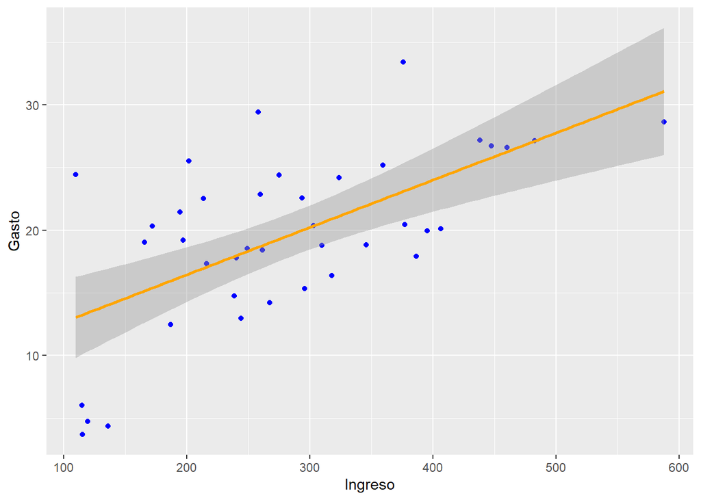

# Agregar una tendencia lineal a un diagrama de dispersión ayuda a ver patrones.

ggplot2 proporciona la geom_smooth() función que permite agregar la tendencia lineal y el intervalo de confianza a su alrededor si es necesario (opción se=TRUE).

Nota: el method argumento permite aplicar diferentes métodos de suavizado como glm, loess y más.(https://www.r-graph-gallery.com/)